# hw2

Author

Nick Kim

Link to my GitHub: https://github.com/nick-kimm/506-HW2.

## Problem 1: Dice Game

Let’s play a dice game. It costs $2 to play. You roll a single 6-sided die.

-On a roll of 3 or 5, you win twice your roll. ex. roll = 3, profit = 3*2 = 6 roll = 5, profit = 5*2 = 10 -On any other roll, you lose.

The input and output should be:

Input: The number of dice to roll. Output: Total winnings

#Part a: #Version 1: Loop

```r
#' Version 1 Dice Game
#'Will implement the Dice Game using a for loop. Will check each index in the simulated rolls and will check if that number if either a 3 or a 5. If it is then it'll increase the total winnings by 2 times the value of the roll. If it neither then it'll subtract 2 from the winnings as that is the cost of this situation.
#'
#' @param x (number of rolls)
#'
#' @return Total Winnings a/f x number of rolls
play_dice <- function(x){
  rolls <- sample(1:6,x,replace=TRUE)
  winnings <- 0
  for (i in 1:x){
    if (rolls[i]==3 | rolls[i]==5){
      winnings <- winnings + rolls[i]*2
    }
    else{
      winnings <- winnings - 2
    }
  }
  return(winnings)
}
```

#Version 2: Vectorized functions in R

```r
#' Version 2 Dice Game
#'Samples the random roll for x number of rolls. Next will calculate the winnings by checking if the roll isn't a 3 or a 5 and then multiplying it by -2 as you'll lose that much in this game. Then it'll add it to the rolls that are 3 or a 5 either by 6 or 10 depending on if you rolled a 3 or a 5. Finally sum over this whole vector to get your total winnings after x rolls
#' @param x
#'
#' @return Total winnings
#'
#' @examples rolls <- 2 5 2 6 4 2 1 3 5 6
#' winnings <- sum(-2 0 -2 -2 -2 -2 -2 0 0 -2 (1st conditionals) + 0 0 0 0 0 0 0 6 0 0 (3 check) + 0 10 0 0 0 0 0 0 10 0 (5 check))
#' winnings <- sum(-2 10 -2 -2 -2 -2 -2 6 10 -2)
#' winnings <- 12
play_dice2 <- function(x){
  rolls <- sample(1:6,x,replace=TRUE)
  winnings <- sum((rolls!=3 & rolls!=5)*-2+(rolls==3)*6+(rolls==5)*10)
  return(winnings)
}
```

#Version 3: Table approach

```r
#' Version 3 Dice Game
#'It'll first convert the rolls to a table with the values 1 to 6 in the first row followed by the count of each of these rolls in the 2nd row. Then the total winnings is calculated by rolls of 3 or 5 multiplied by 4 subtracted by other rolls multiplied by 2.
#' @param x
#'
#' @return Total winnings
#'
#' @examples rolls <- 4 5 6 1 3
#'
#' roll_t <- 1 2 3 4 5 6
#'           1 0 1 1 1 1
#'
#'output <- (1*6 + 1*10) - (1+1+1+1)*2
#'.      <- 8
play_dice3 <- function(x){
  rolls <- sample(1:6,x,replace=TRUE)
  roll_t<-table(factor(rolls, levels = 1:6))
  return((roll_t[["3"]]*6+roll_t[["5"]]*10)-(roll_t[["1"]]+roll_t[["2"]]+roll_t[["4"]]+roll_t[["6"]])*2)
}
```

#Version 4: Apply function

```r
#' Version 4 Dice Game
#'Will create a matrix that will replace any value of a 3 or a 5 to be 6 or 10 respectively and anything else to -2 using the built in ifelse function as that would be how much you would profit or loose in playing this game. Then we'll use the apply function to sum over all these values down the column to get our total winnings.
#' @param x
#'
#' @return Total winnings
#'
#' @examples rolls <- 6 4 6 3 5
#' profit <- [-2 -2 -2 6 10]^T
#' output <- 10
play_dice4 <- function(x){
  rolls <- sample(1:6,x,replace=TRUE)
  profit <- matrix(ifelse(rolls==3,6,ifelse(rolls==5,10,-2)))
  return(apply(profit,2,sum))
}
```

#Part b:

```r
#Version 1 test:
c(play_dice(3),play_dice(3000))
```

```
[1]    2 3840
```

```r
#Version 2 test:
c(play_dice2(3),play_dice2(3000))
```

```
[1]   14 3716
```

```r
#Version 3 test:
c(play_dice3(3),play_dice3(3000))
```

```
[1]   -6 3704
```

```r
#Version 4 test:
c(play_dice4(3),play_dice4(3000))
```

```
[1]   14 3964
```

#Part c: First need to edit the functions above to account for a set seed which we’ll do by adding a another parameter value in the functions we wrote above. This way the randomness will be controlled calling running rolls in each function

```r
seed=0

play_dice_seed <- function(x,seed){
  set.seed(seed)
  rolls <- sample(1:6,x,replace=TRUE)
  winnings <- 0
  for (i in 1:x){
    if (rolls[i]==3 | rolls[i]==5){
      winnings <- winnings + rolls[i]*2
    }
    else{
      winnings <- winnings - 2
    }
  }
  return(winnings)
}

play_dice2_seed <- function(x,seed){
  set.seed(seed)
  rolls <- sample(1:6,x,replace=TRUE)
  winnings <- sum((rolls!=3 & rolls!=5)*-2+(rolls==3)*6+(rolls==5)*10)
  return(winnings)
}

play_dice3_seed <- function(x,seed){
  set.seed(seed)
  rolls <- sample(1:6,x,replace=TRUE)
  roll_t<-table(factor(rolls, levels = 1:6))
  return((roll_t[["3"]]*6+roll_t[["5"]]*10)-(roll_t[["1"]]+roll_t[["2"]]+roll_t[["4"]]+roll_t[["6"]])*2)
}

play_dice4_seed <- function(x,seed){
  set.seed(seed)
  rolls <- sample(1:6,x,replace=TRUE)
  profit <- matrix(ifelse(rolls==3,6,ifelse(rolls==5,10,-2)))
  return(apply(profit,2,sum))
}
```

Next testing if it’ll get the same values

```r
seed = 100

print("v1")
```

```
[1] "v1"
```

```r
c(play_dice_seed(3,seed),play_dice_seed(3000,seed))
```

```
[1]    2 4072
```

```r
print("v2")
```

```
[1] "v2"
```

```r
c(play_dice2_seed(3,seed),play_dice2_seed(3000,seed))
```

```
[1]    2 4072
```

```r
print("v3")
```

```
[1] "v3"
```

```r
c(play_dice3_seed(3,seed),play_dice3_seed(3000,seed))
```

```
[1]    2 4072
```

```r
print("v4")
```

```
[1] "v4"
```

```r
c(play_dice4_seed(3,seed),play_dice4_seed(3000,seed))
```

```
[1]    2 4072
```

#Part d:

Low input: x = 1000

```r
library(microbenchmark)

x <- 1000
seed <- 100

microbenchmark(
  v1 <- play_dice_seed(x,seed),
  v2 <- play_dice2_seed(x,seed),
  v3 <- play_dice3_seed(x,seed),
  v4 <- play_dice4_seed(x,seed)
)
```

```
Unit: microseconds
                           expr     min       lq     mean   median       uq
  v1 <- play_dice_seed(x, seed) 228.769 239.9990 273.8782 256.6335 275.2520
 v2 <- play_dice2_seed(x, seed)  65.762  88.5210 100.9523  94.7885 101.3520
 v3 <- play_dice3_seed(x, seed) 169.388 204.4815 257.7241 229.7640 291.4235
 v4 <- play_dice4_seed(x, seed) 134.324 199.5245 237.6543 222.3450 258.0620
     max neval cld
 507.459   100 a
 197.624   100  b
 557.187   100 a c
 397.261   100   c
```

From the resulting table above in the case x is a low input (1,000). The fastest performing function was v2 or the function using the vectorized functions in R. The next fastest was v4 followed by v3 and lastly v1. From our discussion in class it is no surprise v1 is the slowest as it is reassigning the object winnings for every integer in the vector rolls. The apply function is not too far behind from the vectorized solution and it’s surprising to see the table solution is almost as slow as the looping solution case.

Large input: x = 100,000

```r
x <- 100000
seed <- 100

microbenchmark(
  v1 <- play_dice_seed(x,seed),
  v2 <- play_dice2_seed(x,seed),
  v3 <- play_dice3_seed(x,seed),
  v4 <- play_dice4_seed(x,seed)
)
```

```
Unit: milliseconds
                           expr       min        lq      mean    median
  v1 <- play_dice_seed(x, seed) 21.378325 22.583894 23.907502 23.206826
 v2 <- play_dice2_seed(x, seed)  5.561455  7.062511  7.939553  7.559223
 v3 <- play_dice3_seed(x, seed)  8.169589 10.359453 12.278866 11.036475
 v4 <- play_dice4_seed(x, seed) 10.588785 13.124322 14.706715 14.414433
       uq       max neval  cld
 24.13244  32.50711   100 a
  7.90928  14.06302   100  b
 11.93118 105.01523   100   c
 16.80644  20.28655   100    d
```

#Part e:

```r
nsim <- 10000
x <- sample(1:1000,1)

profit <- vector(length=nsim)

for (i in 1:nsim){
  profit[i] <- play_dice2(x)
}
print(mean(profit))
```

```
[1] 524.5752
```

I think it is more than a fair game because from the mean after multiple simulations you are returning a profit instead of loosing money. If anything this game would be bad for the house as they would be loosing money on average.

##Question 2

#Part a:

```r
cars <- read.csv("/Users/nicholaskim/Documents/STAT 506/HW2/cars.csv")

names(cars) <- c("Height","Length","Width","Dive_type","Engine_type","Is_hybrid","Num_fwd_gears","Trans_type","City_mpg","Fuel_type","Highway_mpg","Manual_or_auto","Car_id","Car_make","Make_n_yr","Model_yr","Horsepower","Torque")
```

#Part b:

```r
cars_r <- cars[cars[,10]=="Gasoline",]
```

#Part c:

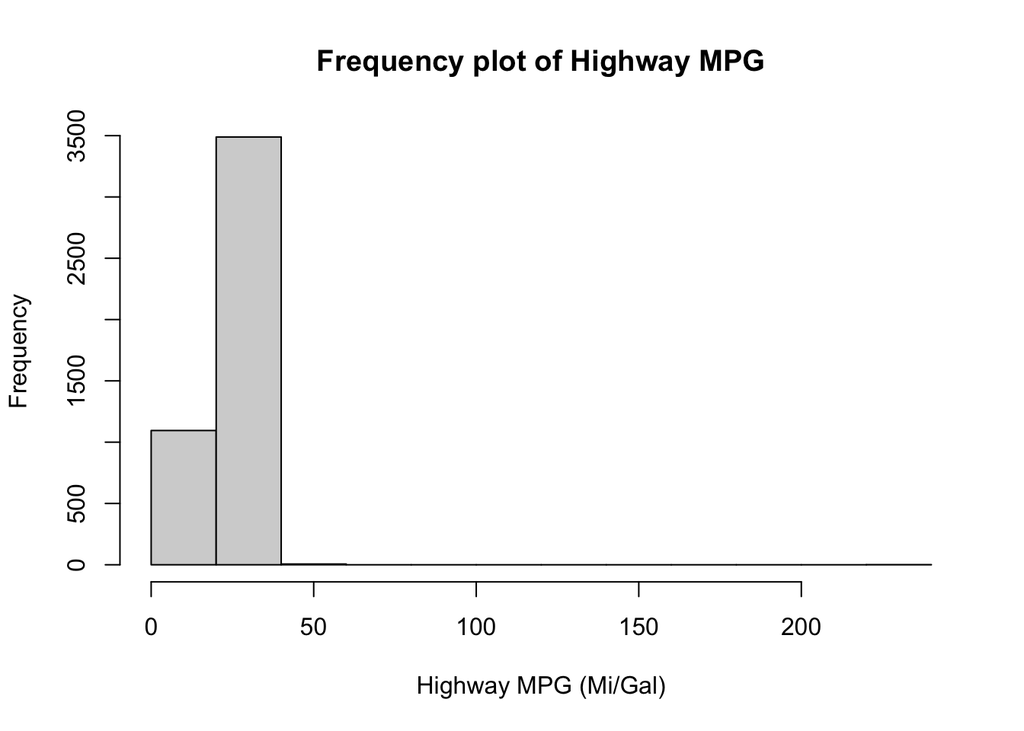

```r
hist(cars_r$Highway_mpg,freq=TRUE,main="Frequency plot of Highway MPG",xlab="Highway MPG (Mi/Gal)")
```

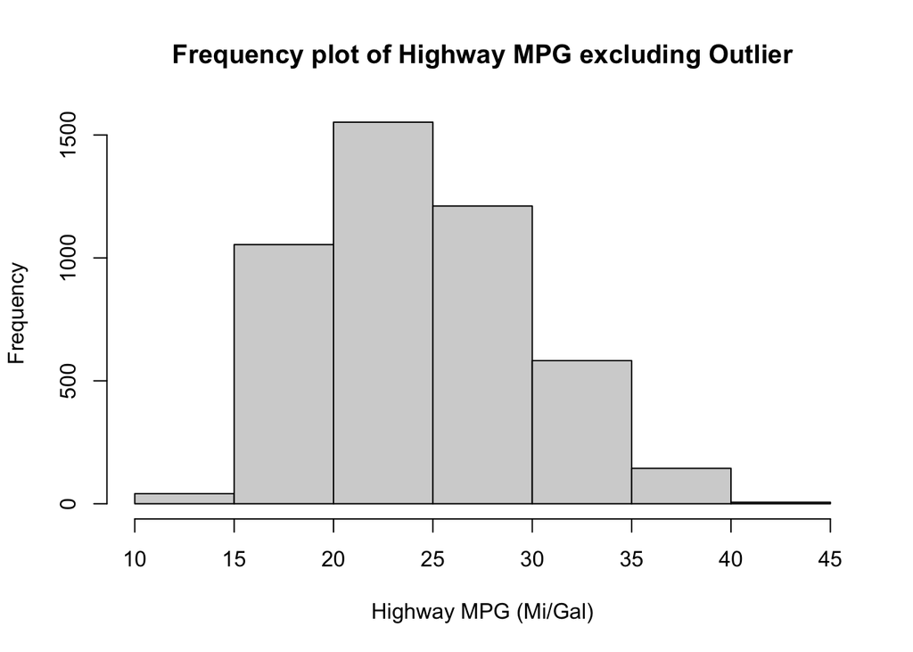

```r
hist(cars_r$Highway_mpg[cars_r$Highway_mpg<100],breaks=10,freq=TRUE,main="Frequency plot of Highway MPG excluding Outlier",xlab="Highway MPG (Mi/Gal)")
```

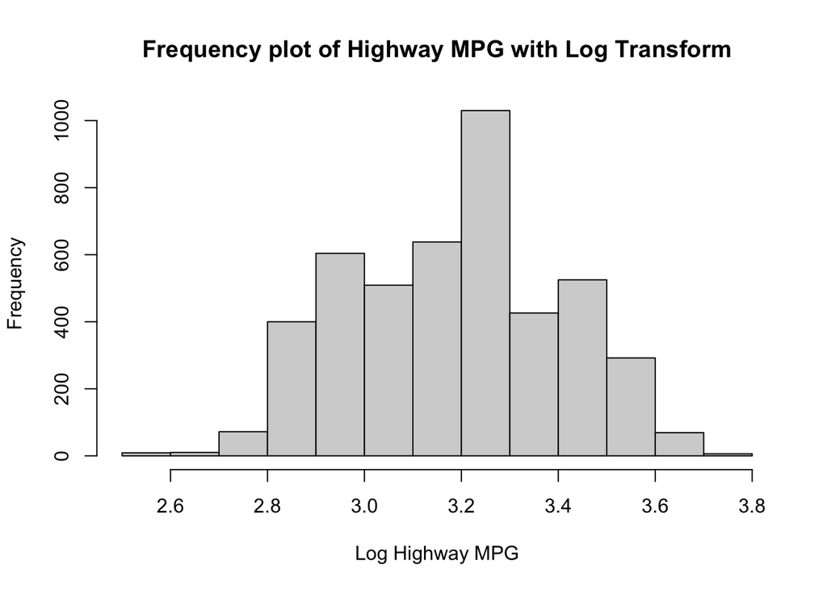

```r
hist(log(cars_r$Highway_mpg[cars_r$Highway_mpg<100]),breaks=10,freq=TRUE,main="Frequency plot of Highway MPG with Log Transform",xlab="Log Highway MPG")
```

From the plot of Highway MPG we can see that there is one outlier point and the data is slightly skewed to the right. Thus it might be best to log transform the variable and remove the outlier to normalize the data.

```r
#removing outlier
cars_r<-cars_r[cars_r$Highway_mpg<100, ]
#log transform of Highway mpg
cars_r$log_hmpg<-log(cars_r$Highway_mpg)
```

#Part d:

```r
model <- lm(log_hmpg~Height+Length+Width+as.factor(Model_yr)+Horsepower+Torque,data=cars_r)
summary(model)
```

```
Call:
lm(formula = log_hmpg ~ Height + Length + Width + as.factor(Model_yr) +
    Horsepower + Torque, data = cars_r)

Residuals:
     Min       1Q   Median       3Q      Max
-0.54934 -0.09280 -0.00387  0.09913  0.76803

Coefficients:
                          Estimate Std. Error t value Pr(>|t|)
(Intercept)              3.508e+00  2.144e-02 163.617  < 2e-16 ***
Height                   4.116e-04  3.344e-05  12.310  < 2e-16 ***
Length                   2.776e-05  2.622e-05   1.059 0.289808
Width                   -9.296e-05  2.684e-05  -3.463 0.000538 ***
as.factor(Model_yr)2010 -2.176e-02  2.008e-02  -1.084 0.278613
as.factor(Model_yr)2011 -3.625e-03  2.005e-02  -0.181 0.856532
as.factor(Model_yr)2012  3.999e-02  2.021e-02   1.979 0.047876 *
Horsepower               9.330e-04  6.757e-05  13.807  < 2e-16 ***
Torque                  -2.306e-03  6.537e-05 -35.279  < 2e-16 ***
---
Signif. codes:  0 '***' 0.001 '**' 0.01 '*' 0.05 '.' 0.1 ' ' 1

Residual standard error: 0.1366 on 4581 degrees of freedom
Multiple R-squared:  0.582, Adjusted R-squared:  0.5813
F-statistic: 797.3 on 8 and 4581 DF,  p-value: < 2.2e-16
```

#Part e:

```r
model2 <- lm(log_hmpg~Torque*Horsepower+Height+Length+Width+Model_yr,data=cars_r)

summary(model2)
```

```
Call:
lm(formula = log_hmpg ~ Torque * Horsepower + Height + Length +
    Width + Model_yr, data = cars_r)

Residuals:
     Min       1Q   Median       3Q      Max
-0.55348 -0.08187 -0.00216  0.08420  0.83538

Coefficients:
                    Estimate Std. Error t value Pr(>|t|)
(Intercept)       -5.259e+01  4.731e+00 -11.115  < 2e-16 ***
Torque            -3.564e-03  7.326e-05 -48.643  < 2e-16 ***
Horsepower        -2.210e-04  7.342e-05  -3.010  0.00263 **
Height             2.905e-04  3.085e-05   9.415  < 2e-16 ***
Length             2.416e-05  2.404e-05   1.005  0.31496
Width             -1.273e-04  2.463e-05  -5.169 2.45e-07 ***
Model_yr           2.807e-02  2.353e-03  11.930  < 2e-16 ***
Torque:Horsepower  3.960e-06  1.339e-07  29.569  < 2e-16 ***
---
Signif. codes:  0 '***' 0.001 '**' 0.01 '*' 0.05 '.' 0.1 ' ' 1

Residual standard error: 0.1254 on 4582 degrees of freedom
Multiple R-squared:  0.6477,    Adjusted R-squared:  0.6472
F-statistic:  1203 on 7 and 4582 DF,  p-value: < 2.2e-16
```

First looking at the range of values for Torque and Horsepower

```r
library(emmeans)
summary(cars_r$Torque)
```

```
   Min. 1st Qu.  Median    Mean 3rd Qu.    Max.
   98.0   177.0   257.0   267.2   331.5   774.0
```

```r
summary(cars_r$Horsepower)
```

```
   Min. 1st Qu.  Median    Mean 3rd Qu.    Max.
  100.0   185.0   263.0   267.5   317.0   638.0
```

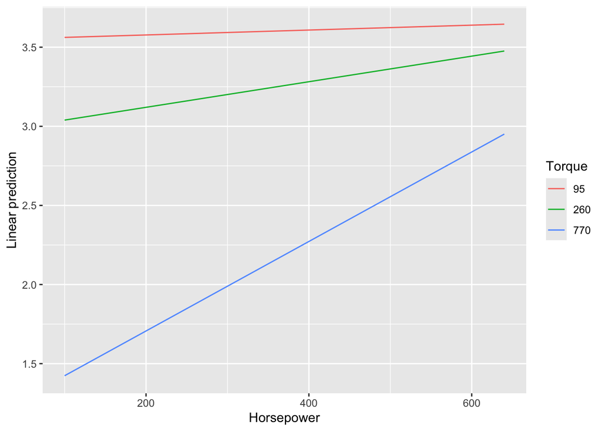

```r
emmip(model2, Torque~Horsepower,at = list(Horsepower = c(100,270,640),Torque = c(95,260,770)))
```

#Part f:

```r
#creating the dummy variables manually for Model years
is_10 <- ifelse(cars_r[,16]==2010,1,0)
is_11 <-ifelse(cars_r[,16]==2011,1,0)
is_12 <- ifelse(cars_r[,16]==2012,1,0)

#creating our design matrix with all other variables in our model excluding our intercept
design_mat <- data.frame(cars_r[,1:3],"2010"=is_10,"2011"=is_11,"2012"=is_12,cars_r[,17:18])

#adding the intercept column in first column to this reduced dataset
#made it a matrix to then do matrix multiplication with
design_mat <- as.matrix(cbind(Intercept = rep(1,nrow(cars_r)), design_mat))

ymat <- cars_r$log_hmpg

beta_hat <- solve(t(design_mat)%*%design_mat)%*%t(design_mat)%*%ymat

data.frame(manual_beta_est = beta_hat,
           lm_beta_est = model$coefficients)
```

```
           manual_beta_est   lm_beta_est
Intercept     3.508331e+00  3.508331e+00
Height        4.115953e-04  4.115953e-04
Length        2.776194e-05  2.776194e-05
Width        -9.295624e-05 -9.295624e-05
X2010        -2.176234e-02 -2.176234e-02
X2011        -3.625194e-03 -3.625194e-03
X2012         3.999171e-02  3.999171e-02
Horsepower    9.329999e-04  9.329999e-04
Torque       -2.306333e-03 -2.306333e-03
```

From the outputs above we can see that the beta estimates from our manual solution is the same as the coefficients from our lm() model. For example, the intercepts are both 3.508331e+00 and Heights are 4.115953e-04 in both our models.